# Specification Part II

## One Slope - One Intercept Model

Let’s start with a basic model and build up to a more complicated model. We can first test whether the fertilizer has any impact on corn growth, ignoring the different types of hybrids for now:

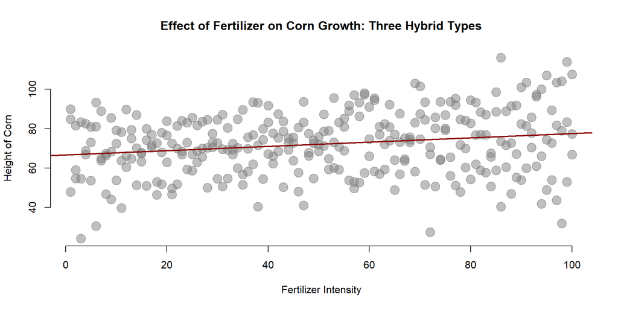

```r
plot( fertilizer, height, col=gray(0.5,0.5), bty="n", cex=2, pch=19,
      xlab="Fertilizer Intensity", ylab="Height of Corn",
      main="Effect of Fertilizer on Corn Growth: Three Hybrid Types")

abline( lm( height ~ fertilizer ), col="darkred", lwd=2 )
```

We can see that we have a positive slope, which is statistically significant. So our fertilize does seem to have a positive effect on the corn.

```r
m.00 <- lm( height ~ fertilizer )


stargazer( m.00, type="html",
           digits=2, omit.stat = c("ser") )
```

|  | *Dependent variable:* |
| --- | --- |
|  | height |
| fertilizer | 0.11*** |
|  | (0.03) |
| Constant | 66.77*** |
|  | (1.80) |
| Observations | 300 |
| R<sup>2</sup> | 0.04 |
| Adjusted R<sup>2</sup> | 0.04 |
| F Statistic | 11.97*** (df = 1; 298) |
| *Note:* | p<0.1; p<0.05; p<0.01 |

## Three Types of Hybrids

Let’s now consider the strength of each type of hybrid.

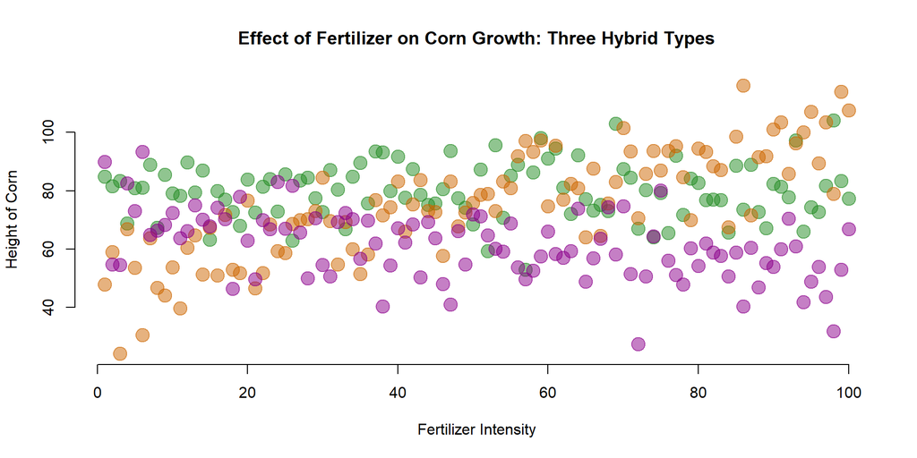

```r
palette( c( adjustcolor( "forestgreen", alpha.f=0.5),
            adjustcolor( "darkorange3", alpha.f=0.5),
            adjustcolor( "darkmagenta", alpha.f=0.5) ) )

plot( fertilizer, height, col=factor(type), pch=19, bty="n", cex=2,
      xlab="Fertilizer Intensity", ylab="Height of Corn",
      main="Effect of Fertilizer on Corn Growth: Three Hybrid Types")
```

## One Slope - Three Intercepts

Let’s extend our original model slightly by still examinig the impact of fertilizer on corn height, but let’s allow each variety to have its own intercept term. We can do this by adding a dummy variable for each hybrid type.

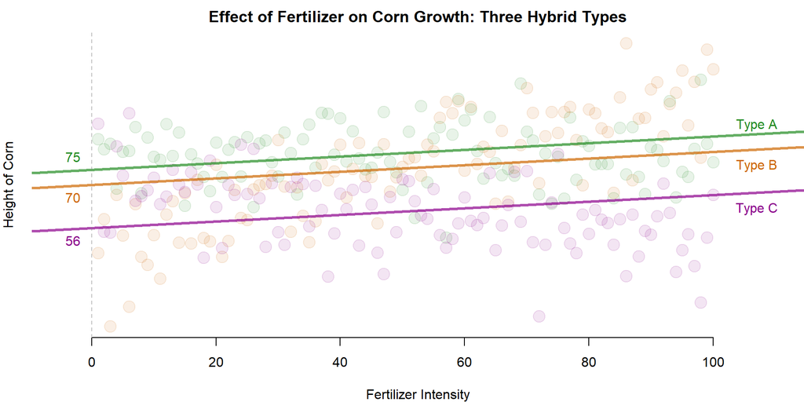

```r
m.01 <- lm( height ~ fertilizer + dumA + dumB )
m.02 <- lm( height ~ fertilizer + dumB + dumC )
m.03 <- lm( height ~ fertilizer + dumC + dumA )
m.04 <- lm( height ~ fertilizer + dumA + dumB + dumC - 1 )


par( mar=c(4,2,2,0) )

palette( c( adjustcolor( "forestgreen", alpha.f=0.1),
            adjustcolor( "darkorange3", alpha.f=0.1),
            adjustcolor( "darkmagenta", alpha.f=0.1) ) )

plot( fertilizer, height, col=factor(type), bty="n", pch=19, cex=2, xlim=c(-5,110),
      xlab="Fertilizer Intensity", ylab="", yaxt="n",
      main="Effect of Fertilizer on Corn Growth: Three Hybrid Types")

title( ylab="Height of Corn", line=1 )

intA <- round( coefficients(m.04)[2], 0 )
intB <- round( coefficients(m.04)[3], 0 )
intC <- round( coefficients(m.04)[4], 0 )

abline( a=intA, b=coefficients(m.04)[1], col=adjustcolor( "forestgreen", alpha.f=0.7), lwd=3 )
abline( a=intB, b=coefficients(m.04)[1], col=adjustcolor( "darkorange3", alpha.f=0.7), lwd=3 )
abline( a=intC, b=coefficients(m.04)[1], col=adjustcolor( "darkmagenta", alpha.f=0.7), lwd=3 )

text( -3, intA, intA, pos=3, col=adjustcolor( "forestgreen", alpha.f=1) )
text( -3, intB, intB, pos=1, col=adjustcolor( "darkorange3", alpha.f=1) )
text( -3, intC, intC, pos=1, col=adjustcolor( "darkmagenta", alpha.f=1) )

text( 107, intA+100*coefficients(m.04)[1], "Type A", pos=3, col=adjustcolor( "forestgreen", alpha.f=1) )
text( 107, intB+100*coefficients(m.04)[1], "Type B", pos=1, col=adjustcolor( "darkorange3", alpha.f=1) )
text( 107, intC+100*coefficients(m.04)[1], "Type C", pos=1, col=adjustcolor( "darkmagenta", alpha.f=1) )

abline( v=0, lty=2, col=gray(0.5,0.5) )
```

```r
stargazer( m.01, m.02, m.03, m.04, type="html",
           digits=2,
          omit.stat=c("f","adj.rsq","ser"),
           intercept.bottom = FALSE )
```

|  | *Dependent variable:* |  |  |  |
| --- | --- | --- | --- | --- |
|  | height |  |  |  |
|  | (1) | (2) | (3) | (4) |
| Constant | 55.72*** | 74.51*** | 70.09*** |  |
|  | (1.89) | (1.89) | (1.89) |  |
| fertilizer | 0.11*** | 0.11*** | 0.11*** | 0.11*** |
|  | (0.03) | (0.03) | (0.03) | (0.03) |
| dumA | 18.79*** |  | 4.42** | 74.51*** |
|  | (1.88) |  | (1.88) | (1.89) |
| dumB | 14.37*** | -4.42** |  | 70.09*** |
|  | (1.88) | (1.88) |  | (1.89) |
| dumC |  | -18.79*** | -14.37*** | 55.72*** |
|  |  | (1.88) | (1.88) | (1.89) |
| Observations | 300 | 300 | 300 | 300 |
| R<sup>2</sup> | 0.30 | 0.30 | 0.30 | 0.97 |
| *Note:* | p<0.1; p<0.05; p<0.01 |  |  |  |

The main thing to note is that this model is more flexible as it does not assume that each type will grow to the same height in the absence of fertilizer (the intercept is where X crosses zero, or where no fertilizer is provided in this case).

We again omit one case. Each dummy variable represents the height that a particular variety will achieve above and beyond the omitted group. If we change the group that we omit it will change the global and group-specific intercept terms in the model, but if you do the math in each case it should result in the same intercept for each group no matter which category is omitted. Rather, it just changes the reference point.

Note, though, that this model one contains one slope. This forces the regression to assume that all varieties of hybrid will respond the same to the fertilizer. This might not be a good assumption, so we can relax this below.